# Exploratory Data Analysis on COVID-19 Data of Morocco

## Mid Semester Examination Assignment

### AS2021574

# **About Morocco**

Morocco, a North African country bordering the Atlantic Ocean and Mediterranean Sea, is distinguished by its Berber, Arabian and European cultural influences. Marrakesh’s medina, a mazelike medieval quarter, offers entertainment in its Djemaa el-Fna square and souks (marketplaces) selling ceramics, jewelry and metal lanterns. The capital Rabat’s Kasbah of the Udayas is a 12th-century royal fort overlooking the water.

- **Location & Geography**

  Morocco is located in the Maghreb region of North Africa. It borders the Mediterranean Sea to the north, the Atlantic Ocean to the west, Algeria to the east, and the disputed territory of Western Sahara to the south. Morocco also claims Spanish exclaves Ceuta, Melilla, and several small islands off its coast. The capital is Rabat, and the largest city is Casablanca.
- **Population & Language**

  Morocco has a population of roughly 37 million. The official and predominant religion is Islam. The official languages are Arabic and Berber, while French and the Moroccan dialect of Arabic are also widely spoken.
- **Cultural Identity**

  Moroccan identity and culture are a blend of Arab, Berber, African, and European influences.
- **Political Structure**

  Morocco is a unitary semi-constitutional monarchy with an elected parliament. The King of Morocco holds significant executive and legislative powers, especially over the military, foreign policy, and religious affairs. The executive branch is led by the King and the Prime Minister. Legislative power is vested in the House of Representatives and the House of Councillors. Judicial power rests with the Constitutional Court, which reviews the validity of laws, elections, and referendums.
- **Economic & Political Influence**

  Morocco has the fifth-largest economy in Africa and wields significant influence in both Africa and the Arab world. It is considered a middle power in global affairs and holds membership in the Arab League, the Arab Maghreb Union, the Union for the Mediterranean, and the African Union.

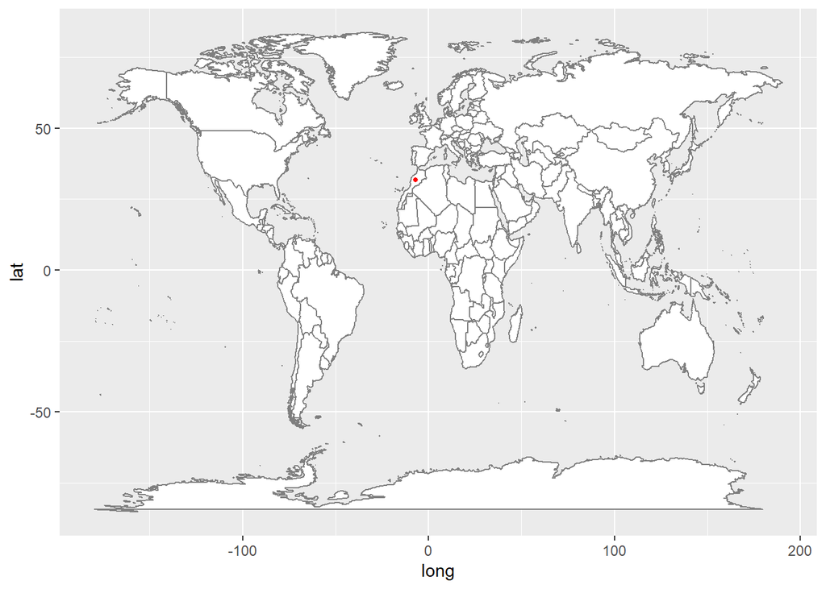

# **Exploratory Data Analysis**

## 1. Dataset `(coronavirus)`

The dataset that has been used, contains the daily summary of Coronavirus cases (confirmed, death, and recovered), by state/province. The source for data is Johns Hopkins University Center for Systems Science and Engineering (JHU CCSE) Coronavirus

## 2. Summary Statistics `

### Confirmed Cases

Summary Statistics for Confirmed Cases in Morocco

| Statistic | Value |
| --- | --- |
| Total Confirmed Cases | 1272490.000 |
| Mean Confirmed Cases | 1113.290 |
| Median Confirmed Cases | 244.000 |
| Standard Deviation of Confirmed Cases | 1922.868 |
| Maximum Confirmed Cases | 12039.000 |
| Minimum Confirmed Cases | 0.000 |

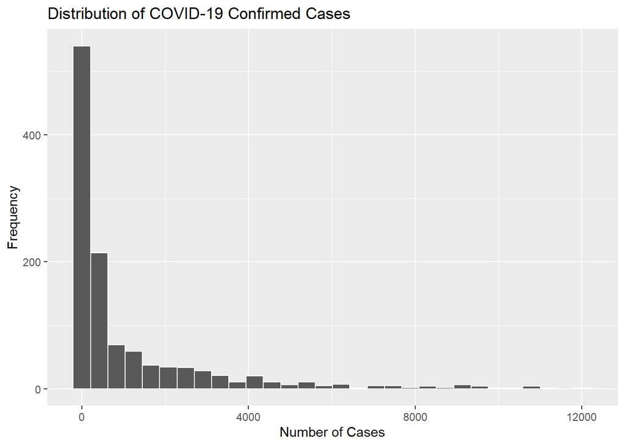

By analyzing above histogram and the summary statistics, we can observe that COVID-19 “Confirmed” cases shows a positively skiwed distribution, with a mean value of 1113.29. There were total of 1272490 confirmed cases reported according to the data.

### Death Cases

Summary Statistics for Death Cases in Morocco

| Statistic | Value |
| --- | --- |
| Total Death Cases | 16296.00000 |
| Mean Death Cases | 14.25722 |
| Median Death Cases | 3.00000 |
| Standard Deviation of Death Cases | 23.16722 |
| Maximum Death Cases | 127.00000 |
| Minimum Death Cases | 0.00000 |

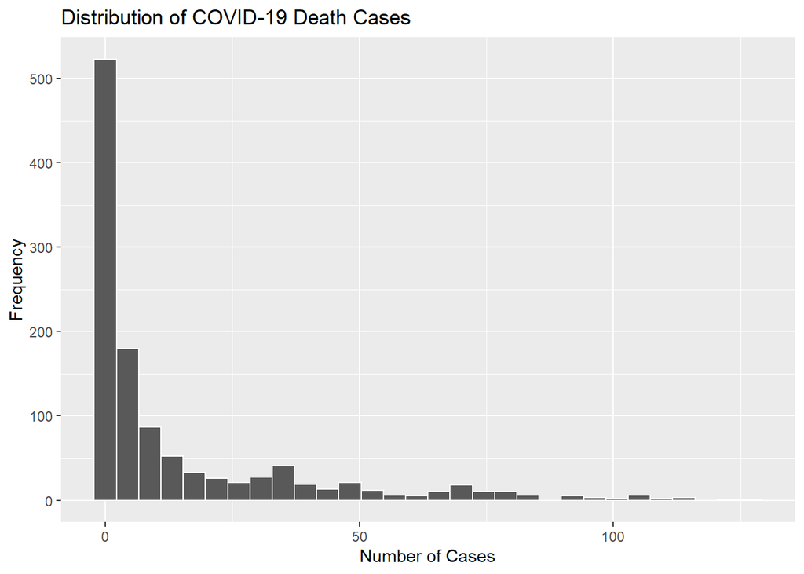

By analyzing above histogram and the summary statistics, we can observe that COVID-19 “Death” cases shows a positively skiwed distribution, with a mean value of 14.257. There were total of 16296 death cases reported according to the data.

### Recovered Cases

Summary Statistics for Recovered Cases in Morocco

| Statistic | Value |
| --- | --- |
| Total Recovered Cases | 582692.0000 |
| Mean Recovered Cases | 509.7918 |
| Median Recovered Cases | 0.0000 |
| Standard Deviation of Recovered Cases | 1052.3359 |
| Maximum Recovered Cases | 7774.0000 |
| Minimum Recovered Cases | 0.0000 |

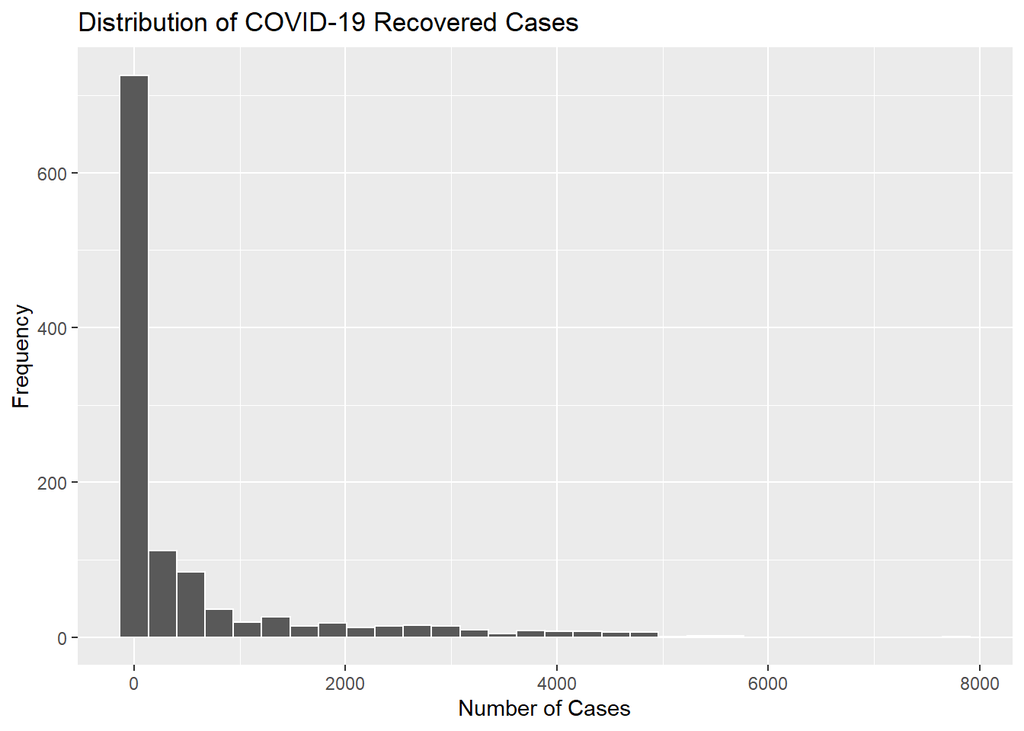

By analyzing above histogram and the summary statistics, we can observe that COVID-19 “Recovered” cases shows a positively skiwed distribution, with a mean value of 509.79.There were total of 582692 recovered cases reported according to the data.

## 3. Time Series Analysis

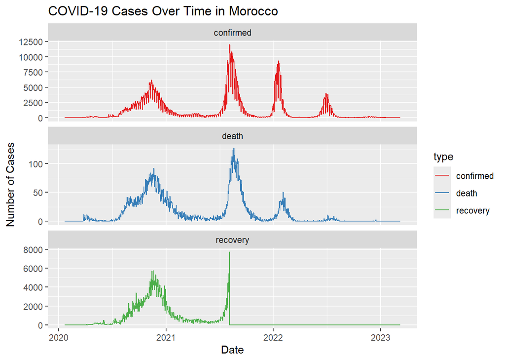

Morocco’s Confirmed and Death Cases plot shows how the pandemic evolved with 4 significant waves. The confirmed cases’ waves are followed by the waves in death cases, although the magnitude of deaths is significantly lower than that of confirmed cases

The plot of Recovered Cases shows that the data of recovered cases were missing since mid-2021. There for it is hard to interpret on the Recovered Cases.

### Percerntage of Confirmed cases per Population among countries

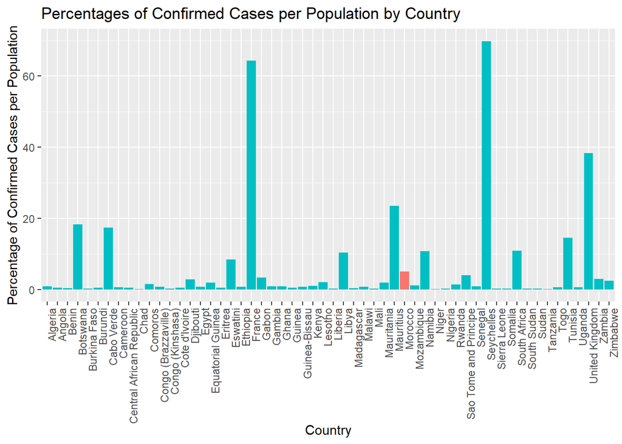

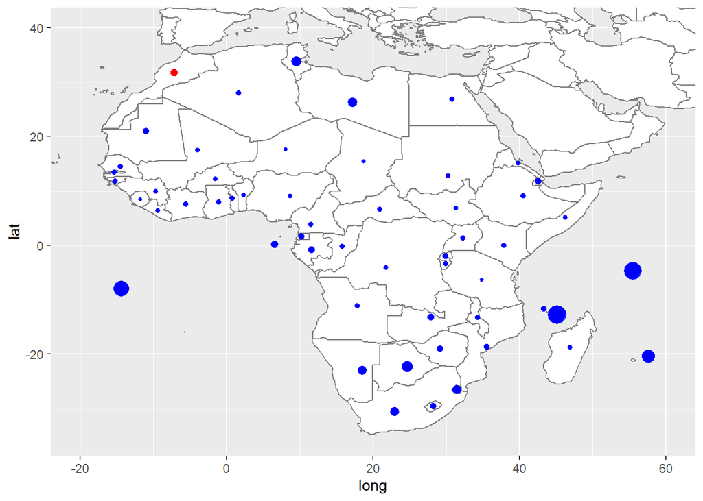

## 5. Correlation Analysis

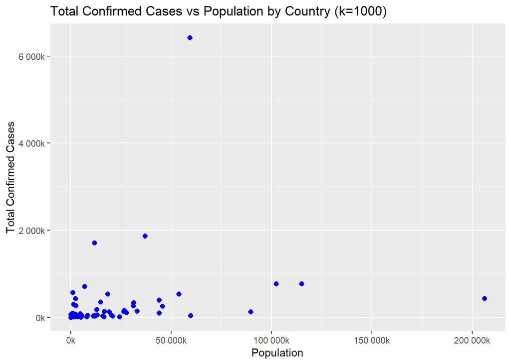

By observing the scatter plot between Total Confirmed Cases of each country in the Continent of Africa and the Population , we can’t see any relationship

# **Conclusion and Discussion**

## Discussion

Although Morocco Data didn’t show any negative values, when using other African continent values, it was observed that there are negative values in the cases column. There for, the absolute value of the such cases are used for calculations and plotting

# **Reference**

- https://en.wikipedia.org/wiki/Morocco
- https://thiyangt.github.io/geom.encyclopedia/
- https://github.com/RamiKrispin/coronavirus
- https://bookdown.org/yihui/rmarkdown-cookbook/kable.html